# What YouTube videos make the trending section in the United States?

## Introduction

Trending YouTube videos capture what is going on in the world through a variety of different categories. YouTube videos are something that almost everyone in the United States is familiar with. However, the types of videos and **the logistics behind the videos that make the trending section are not as well known**. In this report we will analyze what factors support videos making it into YouTube’s trending section *through summaries, tables, and visual representations* of our findings from our data set. The data set we will be using to conduct this analysis was created and organized by [Rishav Sharma.](https://www.kaggle.com/rsrishav/youtube-trending-video-dataset?select=US_youtube_trending_data.csv) We pulled the data set on November 14th, 2020 and thus the data we are analyzing contains values from August 12th, 2020 to November 14th, 2020. It is important to note that our analysis is only for videos **in the United States** and does not contain correlations between the factors we are analyzing and other countries.

## Charts

### Doughnut Graph

This doughnut graph displays the distribution of each video category found within the trending section. From looking at the graph, it is clear to see that the majority of videos that make it into the trending section are **Music, Entertainment, and Sports**, with the combination of the three making up over 50% of the fifteen unique categories that were found in our data.

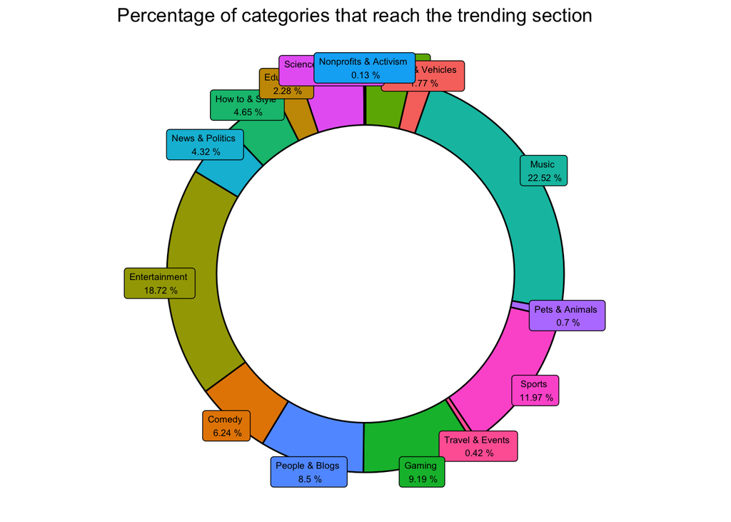

### Average Viewership Per Day

This plot displays the average amount of views trending videos recieved on a given day (Sunday to Saturday). We created this chart to see if there is a relationship between average viewership and the day of the week.

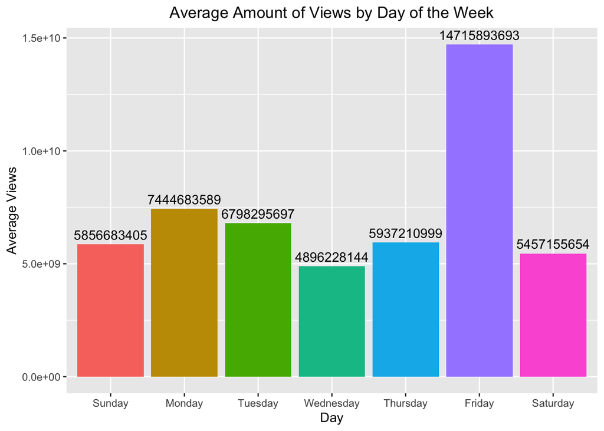

This graph clearly shows that trending videos on Friday recieve nearly triple the average viewership. Additionally, Wednesday is a particularly slow day for YouTube videos. This may mean that popular creators should attempt to have a video on the trending page every Friday because this is when they would likely recieve the highest viewership.